# Choice of alpha and cooling parameter

#### **cooling parameter**

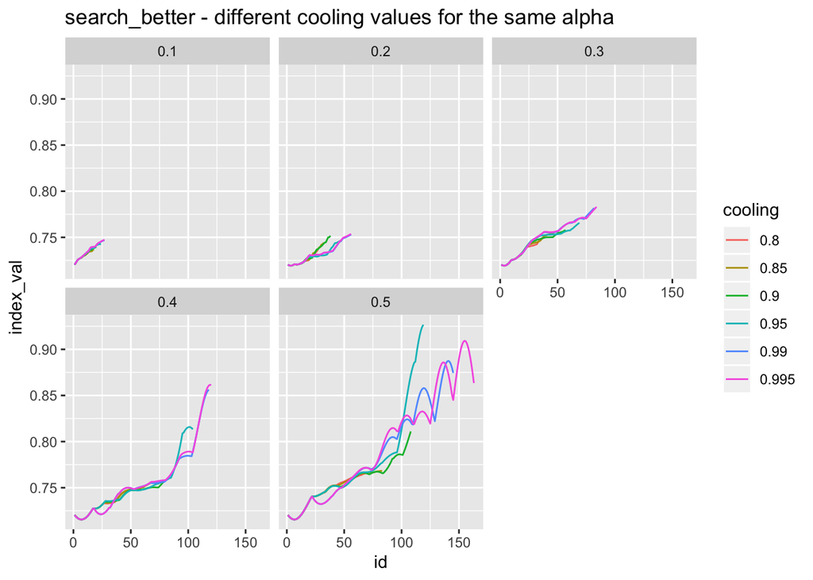

```r
better_interp <- better_alpha %>%
  filter(info == "interpolation") %>%
  group_by(alpha, cooling) %>%
  mutate(id = row_number()) %>%
  ungroup() %>%
  mutate(alpha = as.factor(alpha),
         cooling = as.factor(cooling))

random_interp <- better_random_alpha %>%
  filter(info == "interpolation") %>%
  group_by(alpha, cooling) %>%
  mutate(id = row_number()) %>%
  ungroup() %>%
  mutate(alpha = as.factor(alpha),
         cooling = as.factor(cooling))

better_interp %>%
  ggplot(aes(x = id, y = index_val, col = cooling)) +
  geom_line() +
  facet_wrap(vars(alpha)) +
  ggtitle("search_better - different cooling values for the same alpha")
```

```r
random_interp %>%
  ggplot(aes(x = id, y = index_val, col = cooling)) +
  geom_line() +
  facet_wrap(vars(alpha)) +
  ggtitle("search_better_random - different cooling values for the same alpha")
```

[output not shown]

#### **alpha parameter**

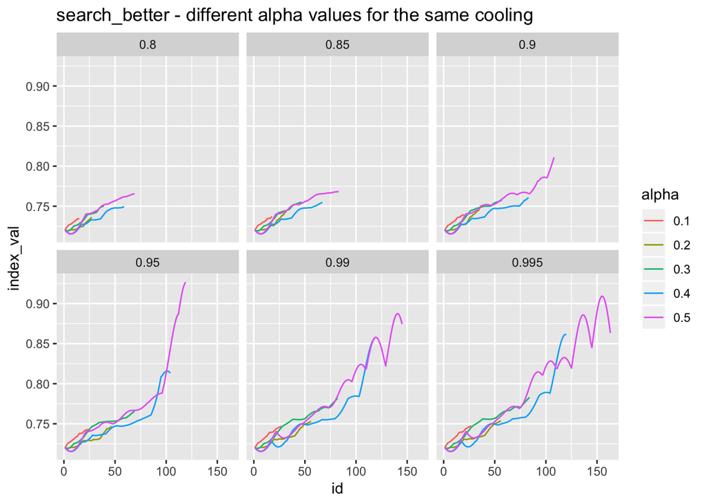

```r
better_interp %>%
  ggplot(aes(x = id, y = index_val, col = alpha)) +
  geom_line() +
  facet_wrap(vars(cooling)) +
  ggtitle("search_better - different alpha values for the same cooling")
```

```r
random_interp %>%
  ggplot(aes(x = id, y = index_val, col = alpha)) +
  geom_line() +
  facet_wrap(vars(cooling)) +
  ggtitle("search_better_random - different alpha values for the same cooling")
```

[output not shown]

#### **ending index_val**

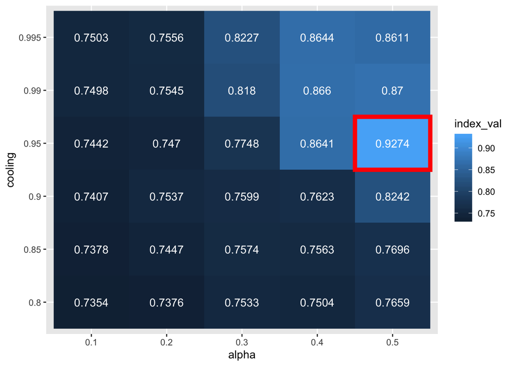

```r
max_index_val <- better_alpha %>%
  filter(info == "new_basis") %>%
  group_by(alpha, cooling) %>%
  filter(index_val == max(index_val)) %>%
  ungroup() %>%
  mutate(alpha = as.factor(alpha),
         cooling = as.factor(cooling))

best_better <- max_index_val %>% filter(index_val == max(index_val))

max_index_val %>%
  ggplot(aes(x = alpha, y = cooling)) +
  geom_raster(aes(fill = index_val)) +
  geom_tile(data = best_better, size = 2, fill = NA, col = "red") +
  geom_text(aes(label = round(index_val, 4)), col = "white")
```

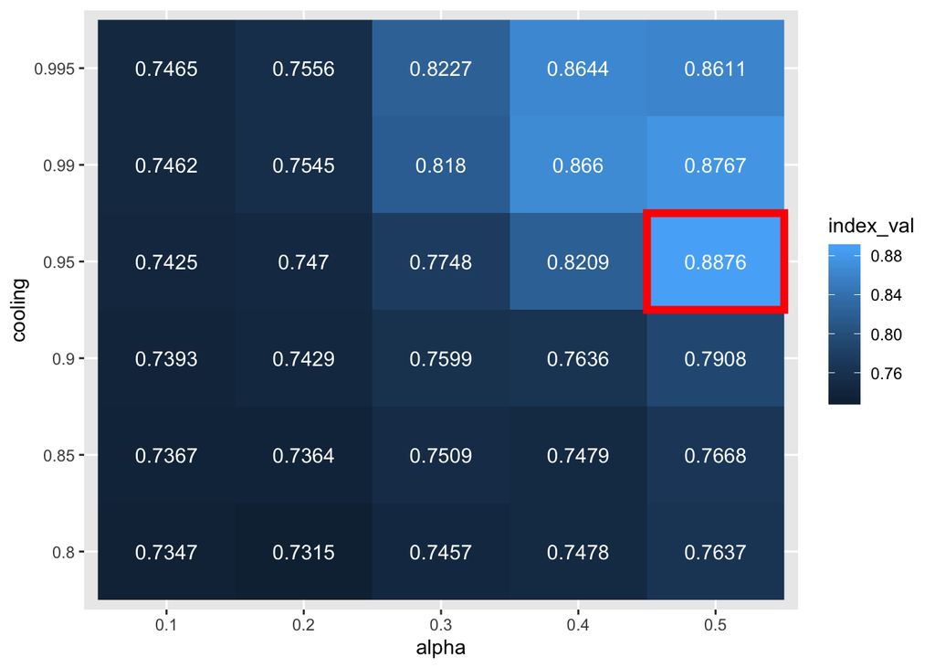

```r
random_max_index_val <- better_random_alpha %>%
  filter(info == "new_basis") %>%
  group_by(alpha, cooling) %>%
  filter(index_val == max(index_val)) %>%
  ungroup() %>%
  mutate(alpha = as.factor(alpha),
         cooling = as.factor(cooling))

best_random <- random_max_index_val %>% filter(index_val == max(index_val))

random_max_index_val %>%
  ggplot(aes(x = alpha, y = cooling)) +
  geom_raster(aes(fill = index_val)) +
  geom_tile(data = best_random, size = 2, fill = NA, col = "red") +
  geom_text(aes(label = round(index_val, 4)), col = "white")
```

### **2. Comparison between `search_better()` and `search_better_random()`**

- For a small alpha value, 0.1, the trigger of random step in `search_better_random` doesn’t result in a larger ending index_val.
- For combination of large cooling and alpha value, `search_better_random` is doing the same as `search_better`. This is because when the searching neighbourhood becomes large, the searching algorithm is likely to find a much better index_val that result in a large difference in `new_index-cur_index`.
- We could also play around with different eps value to see if things would change if eps is larger.

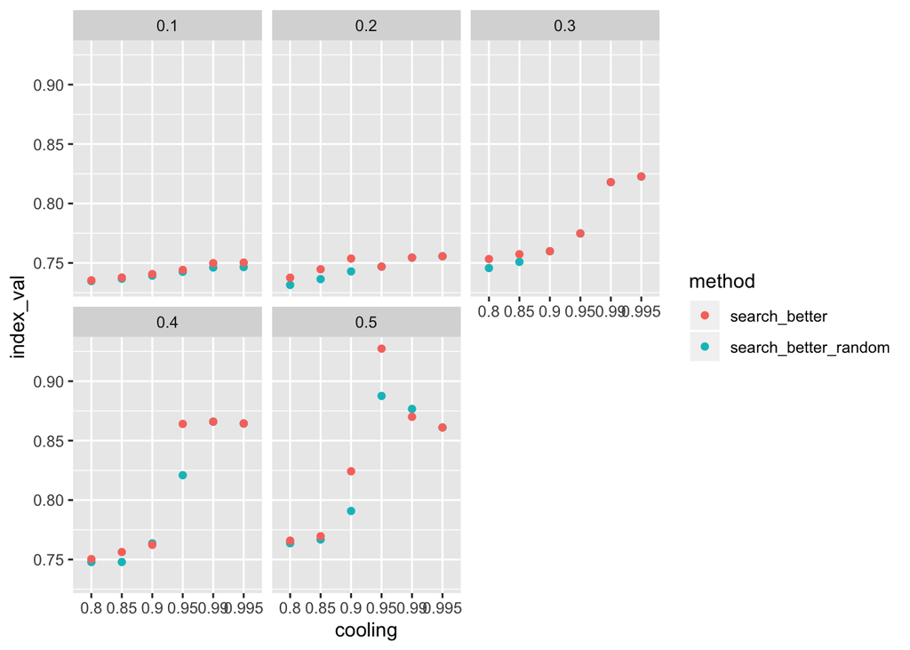

```r
bind_rows(random_max_index_val,max_index_val) %>%
  ggplot(aes(x = cooling , y = index_val, col = method)) +
  geom_point() +
  facet_wrap(vars(alpha))
```

```r
bind_rows(random_max_index_val,max_index_val) %>%
  ggplot(aes(x = alpha , y = index_val, col = method)) +
  geom_point() +
  facet_wrap(vars(cooling))
```

[output not shown]

### **3. A starting value of `stepS = 0.01` is also too small for search_geodesic()**

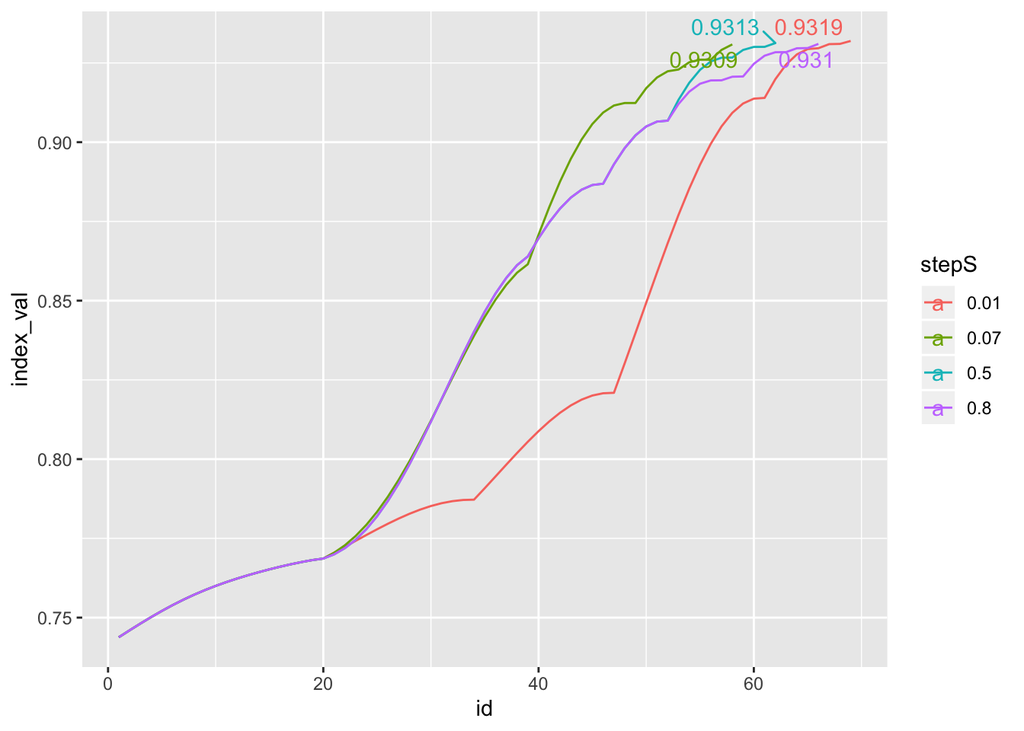

```r
geodesic_clean <- geodesic_alpha2 %>%
  filter(info == "interpolation") %>%
  mutate(stepS = as.factor(stepS))

best <- geodesic_clean %>%
  group_by(stepS) %>%
  mutate(id = row_number()) %>%
  filter(index_val == max(index_val))

nondup <- best %>%
  ungroup() %>%
  mutate(dup = duplicated(round(index_val, 4))) %>%
  filter(dup == FALSE)

geodesic_interp <- geodesic_clean %>%
   filter(stepS %in% nondup$stepS) %>%
  group_by(stepS) %>%
  mutate(id = row_number())

geodesic_interp %>%
  ggplot(aes(x = id, y = index_val, col = stepS)) +
  geom_path() +
  ggrepel::geom_text_repel(data = nondup,
                           aes(label = round(index_val, 4)))
```

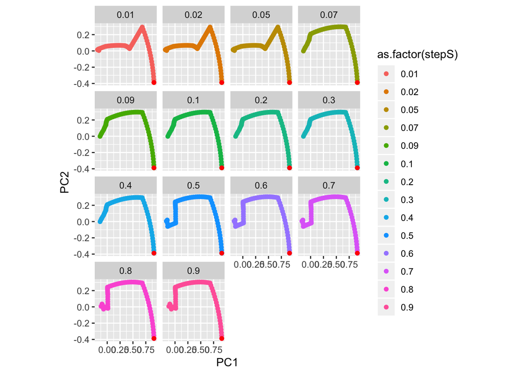

```r
pca2 <- geodesic_alpha2 %>%
  pca_geodesic() %>%
  filter(info %in% c("start", "interpolation"))

pca2 %>%
  ggplot(aes(x= PC1, y = PC2, col = as.factor(stepS))) +
  geom_point() +
  geom_point(data = filter(pca2, info == "start"), col = "red") +
  theme(aspect.ratio = 1) +
  facet_wrap(vars(stepS))
```

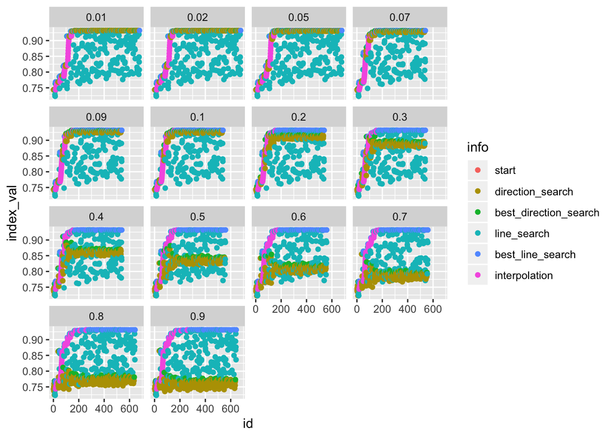

```r
geodesic_alpha2 %>%
  group_by(stepS) %>%
  mutate(id = row_number()) %>%
  ggplot(aes(x = id, y = index_val, col = info)) +
  geom_point() +
  facet_wrap(vars(stepS))
```

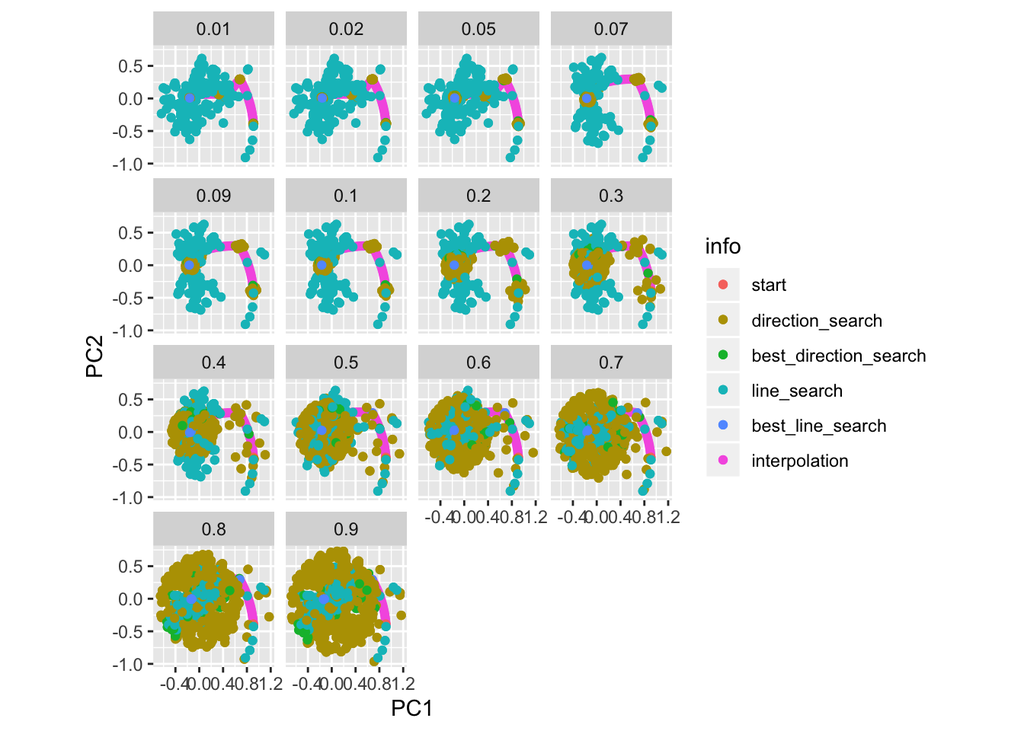

```r
x2_object <- geodesic_alpha2 %>%
  group_by(stepS) %>%
  pca_geodesic()

x2_releveled <- x2_object %>% filter(info != "interpolation")

x2_object %>%
  ggplot(aes(x= PC1, y = PC2, col = info)) +
  geom_point() +
  geom_point(data = x2_releveled) +
  theme(aspect.ratio = 1) +
  facet_wrap(vars(stepS))
```